# Classification of Qualitative Analysis of Human Activity Recognition of Exercise Routines

John Lovrinic

Thursday, October 15, 2015

## Summary

This paper presents an analysis of data from the Human Activity Recognition Project WLE dataset:

Velloso, E.; Bulling, A.; Gellersen, H.; Ugulino, W.; Fuks, H. [Qualitative Activity Recognition of Weight Lifting Exercises](http://groupware.les.inf.puc-rio.br/work.jsf?p1=11201). Proceedings of 4th International Conference in Cooperation with SIGCHI (Augmented Human ’13) . Stuttgart, Germany: ACM SIGCHI, 2013.

Read more about this project at [Groupware->Projects->HAR](http://groupware.les.inf.puc-rio.br/har#sbia_paper_section).

Our objective is to attempt to classify the the manner of the exercises performed (correctly or which manner of incorrectness), based on the qualitative information provided by the data set. The test data consists of the 6 participants performing Unilateral Dumbbell Biceps Curl in five different fashions:

- Class A - exactly according to the specification (correct)
- Class B - throwing the elbows to the front (incorrect)
- Class C - lifting the dumbbell only halfway (incorrect)
- Class D - lowering the dumbbell only halfway (incorrect)
- Class E - throwing the hips to the front (incorrect)

## Analysis

### Preprocessing

```r
names(training)
```

```
##  [1] "roll_belt"            "pitch_belt"           "yaw_belt"
##  [4] "total_accel_belt"     "gyros_belt_x"         "gyros_belt_y"
##  [7] "gyros_belt_z"         "accel_belt_x"         "accel_belt_y"
## [10] "accel_belt_z"         "magnet_belt_x"        "magnet_belt_y"
## [13] "magnet_belt_z"        "roll_arm"             "pitch_arm"
## [16] "yaw_arm"              "total_accel_arm"      "gyros_arm_x"
## [19] "gyros_arm_y"          "gyros_arm_z"          "accel_arm_x"
## [22] "accel_arm_y"          "accel_arm_z"          "magnet_arm_x"
## [25] "magnet_arm_y"         "magnet_arm_z"         "roll_dumbbell"
## [28] "pitch_dumbbell"       "yaw_dumbbell"         "total_accel_dumbbell"
## [31] "gyros_dumbbell_x"     "gyros_dumbbell_y"     "gyros_dumbbell_z"
## [34] "accel_dumbbell_x"     "accel_dumbbell_y"     "accel_dumbbell_z"
## [37] "magnet_dumbbell_x"    "magnet_dumbbell_y"    "magnet_dumbbell_z"
## [40] "roll_forearm"         "pitch_forearm"        "yaw_forearm"
## [43] "total_accel_forearm"  "gyros_forearm_x"      "gyros_forearm_y"
## [46] "gyros_forearm_z"      "accel_forearm_x"      "accel_forearm_y"
## [49] "accel_forearm_z"      "magnet_forearm_x"     "magnet_forearm_y"
## [52] "magnet_forearm_z"     "classe"
```

### Model Fitting

#### Initial Efforts

Given this was a classification problem with more than 2 resultant classes, it was decided to explore an rpart and a random forest solution. Prior to breaking down the data into training and test sets and for each training run, we set the seed to 12432. We started with a 60/40 training/test split and employing the rpart method. While quick, accuracy was less than 50% and so not acceptable. Switching to the random forest method, accuracy jumped to 95%, but execution time also climbed to over an hour. At this time a 70/30 training/test split was attempted and this gave satisfactory results with accuracy of over 99% and execution time climbing no higher.

A breakdown of the findings follows.

Confusion Matrix

```r
confusionMatrix(pred,reference=testing$classe)
```

```
## Confusion Matrix and Statistics
##
##           Reference
## Prediction    A    B    C    D    E
##          A 1672    4    0    0    0
##          B    0 1132    5    0    1
##          C    1    3 1020    9    1
##          D    0    0    1  953    1
##          E    1    0    0    2 1079
##
## Overall Statistics
##
##                Accuracy : 0.9951
##                  95% CI : (0.9929, 0.9967)
##     No Information Rate : 0.2845
##     P-Value [Acc > NIR] : < 2.2e-16
##
##                   Kappa : 0.9938
##  Mcnemar's Test P-Value : NA
##
## Statistics by Class:
##
##                      Class: A Class: B Class: C Class: D Class: E
## Sensitivity            0.9988   0.9939   0.9942   0.9886   0.9972
## Specificity            0.9991   0.9987   0.9971   0.9996   0.9994
## Pos Pred Value         0.9976   0.9947   0.9865   0.9979   0.9972
## Neg Pred Value         0.9995   0.9985   0.9988   0.9978   0.9994
## Prevalence             0.2845   0.1935   0.1743   0.1638   0.1839
## Detection Rate         0.2841   0.1924   0.1733   0.1619   0.1833
## Detection Prevalence   0.2848   0.1934   0.1757   0.1623   0.1839
## Balanced Accuracy      0.9989   0.9963   0.9956   0.9941   0.9983
```

```r
result
```

```
##
## Call:
##  randomForest(x = x, y = y, mtry = param$mtry)
##                Type of random forest: classification
##                      Number of trees: 500
## No. of variables tried at each split: 27
##
##         OOB estimate of  error rate: 0.73%
## Confusion matrix:
##      A    B    C    D    E class.error
## A 3898    5    2    0    1 0.002048131
## B   20 2632    5    1    0 0.009781791
## C    0   15 2370   11    0 0.010851419
## D    0    0   26 2226    0 0.011545293
## E    0    1    5    8 2511 0.005544554
```

#### Determining Final Model

Now that we have a working model, it was decided to try and improve operational efficiency while not losing too much accuracy. To achieve that we did some analysis on the model.

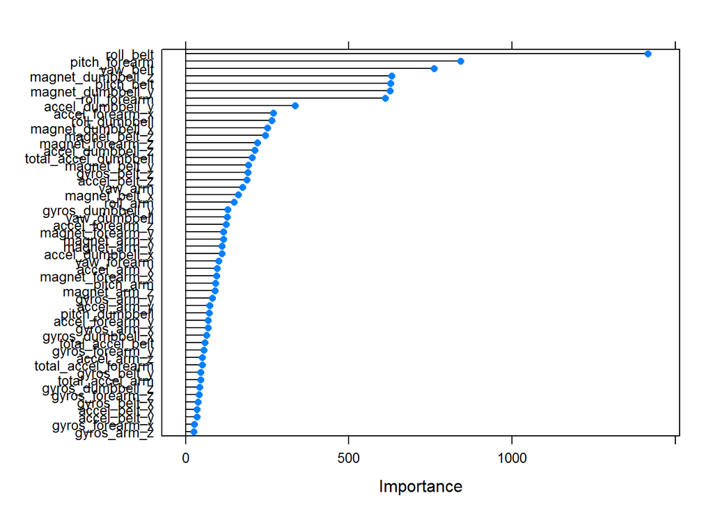

```r
imp<-varImp(modfit,scale=FALSE)
plot(imp)
```

```r
result2
```

```
##
## Call:
##  randomForest(x = x, y = y, mtry = param$mtry)
##                Type of random forest: classification
##                      Number of trees: 500
## No. of variables tried at each split: 2
##
##         OOB estimate of  error rate: 1.08%
## Confusion matrix:
##      A    B    C    D    E class.error
## A 3897    7    0    1    1 0.002304147
## B   31 2602   25    0    0 0.021068473
## C    0   24 2362   10    0 0.014190317
## D    0    1   29 2221    1 0.013765542
## E    0    3    6    9 2507 0.007128713
```

```r
confusionMatrix(pred2,reference=testing2$classe)
```

```
## Confusion Matrix and Statistics
##
##           Reference
## Prediction    A    B    C    D    E
##          A 1667    7    0    0    0
##          B    5 1121    6    0    0
##          C    0   10 1018   12    2
##          D    2    1    2  952    3
##          E    0    0    0    0 1077
##
## Overall Statistics
##
##                Accuracy : 0.9915
##                  95% CI : (0.9888, 0.9937)
##     No Information Rate : 0.2845
##     P-Value [Acc > NIR] : < 2.2e-16
##
##                   Kappa : 0.9893
##  Mcnemar's Test P-Value : NA
##
## Statistics by Class:
##
##                      Class: A Class: B Class: C Class: D Class: E
## Sensitivity            0.9958   0.9842   0.9922   0.9876   0.9954
## Specificity            0.9983   0.9977   0.9951   0.9984   1.0000
## Pos Pred Value         0.9958   0.9903   0.9770   0.9917   1.0000
## Neg Pred Value         0.9983   0.9962   0.9983   0.9976   0.9990
## Prevalence             0.2845   0.1935   0.1743   0.1638   0.1839
## Detection Rate         0.2833   0.1905   0.1730   0.1618   0.1830
## Detection Prevalence   0.2845   0.1924   0.1771   0.1631   0.1830
## Balanced Accuracy      0.9971   0.9909   0.9936   0.9930   0.9977
```

```r
varImp(modfit2)
```

```
## rf variable importance
##
##                      Overall
## roll_belt            100.000
## yaw_belt              79.147
## magnet_dumbbell_z     57.329
## pitch_belt            56.679
## pitch_forearm         50.395
## magnet_dumbbell_y     47.610
## roll_forearm          40.845
## magnet_dumbbell_x     34.558
## accel_belt_z          26.289
## magnet_belt_z         21.670
## roll_dumbbell         20.998
## accel_dumbbell_y      19.882
## magnet_belt_y         18.038
## accel_dumbbell_z      16.842
## roll_arm              16.089
## accel_forearm_x       13.303
## magnet_forearm_z      10.870
## magnet_belt_x          7.693
## total_accel_dumbbell   0.000
```

One more attempt was done, this time with only 7 properties, and that also gave very good results.

```r
result3
```

```
##
## Call:
##  randomForest(x = x, y = y, mtry = param$mtry)
##                Type of random forest: classification
##                      Number of trees: 500
## No. of variables tried at each split: 2
##
##         OOB estimate of  error rate: 1.55%
## Confusion matrix:
##      A    B    C    D    E class.error
## A 3872   11   20    3    0 0.008704557
## B   30 2577   36   12    3 0.030474041
## C    4   18 2360   14    0 0.015025042
## D    0    6   20 2223    3 0.012877442
## E    0   21    5    7 2492 0.013069307
```

```r
confusionMatrix(pred3,reference=testing3$classe)
```

```
## Confusion Matrix and Statistics
##
##           Reference
## Prediction    A    B    C    D    E
##          A 1658    6    5    0    0
##          B    6 1114    5    1    6
##          C    8   12 1007    4    6
##          D    2    7    9  956    4
##          E    0    0    0    3 1066
##
## Overall Statistics
##
##                Accuracy : 0.9857
##                  95% CI : (0.9824, 0.9886)
##     No Information Rate : 0.2845
##     P-Value [Acc > NIR] : < 2.2e-16
##
##                   Kappa : 0.9819
##  Mcnemar's Test P-Value : NA
##
## Statistics by Class:
##
##                      Class: A Class: B Class: C Class: D Class: E
## Sensitivity            0.9904   0.9781   0.9815   0.9917   0.9852
## Specificity            0.9974   0.9962   0.9938   0.9955   0.9994
## Pos Pred Value         0.9934   0.9841   0.9711   0.9775   0.9972
## Neg Pred Value         0.9962   0.9947   0.9961   0.9984   0.9967
## Prevalence             0.2845   0.1935   0.1743   0.1638   0.1839
## Detection Rate         0.2817   0.1893   0.1711   0.1624   0.1811
## Detection Prevalence   0.2836   0.1924   0.1762   0.1662   0.1816
## Balanced Accuracy      0.9939   0.9871   0.9877   0.9936   0.9923
```

```r
varImp(modfit3)
```

```
## rf variable importance
##
##                   Overall
## roll_belt          100.00
## yaw_belt            61.95
## pitch_belt          28.17
## magnet_dumbbell_y   22.74
## pitch_forearm       16.33
## magnet_dumbbell_z   15.42
## roll_forearm         0.00
```

## Conclusion

We see that the accuracy and kappa values are still well above 95%, and that our p value is almost non-existant. This would lead us to expect that we have found a good but not too expensive to obtain model.